# R Assignment - LA1

## This is a notebook which executes various commands and visulization on the student data

```r
summary(df)
```

```
    school          school_setting     school_type         classroom         teaching_method      n_student
 Length:2133        Length:2133        Length:2133        Length:2133        Length:2133        Min.   :14.0
 Class :character   Class :character   Class :character   Class :character   Class :character   1st Qu.:20.0
 Mode  :character   Mode  :character   Mode  :character   Mode  :character   Mode  :character   Median :22.0
                                                                                                Mean   :22.8
                                                                                                3rd Qu.:27.0
                                                                                                Max.   :31.0
  student_id           gender             lunch              pretest         posttest
 Length:2133        Length:2133        Length:2133        Min.   :22.00   Min.   : 32.0
 Class :character   Class :character   Class :character   1st Qu.:44.00   1st Qu.: 56.0
 Mode  :character   Mode  :character   Mode  :character   Median :56.00   Median : 68.0
                                                          Mean   :54.96   Mean   : 67.1
                                                          3rd Qu.:65.00   3rd Qu.: 77.0
                                                          Max.   :93.00   Max.   :100.0
```

```r
head(df)
```

|  | school | school_setting | school_type | classroom | teaching_method | n_student | student_id | gender | lunch | pretest | posttest |
| --- | --- | --- | --- | --- | --- | --- | --- | --- | --- | --- | --- |
| 1 | ANKYI | Urban | Non-public | 6OL | Standard | 20 | 2FHT3 | Female | Does not qualify | 62 | 72 |
| 2 | ANKYI | Urban | Non-public | 6OL | Standard | 20 | 3JIVH | Female | Does not qualify | 66 | 79 |
| 3 | ANKYI | Urban | Non-public | 6OL | Standard | 20 | 3XOWE | Male | Does not qualify | 64 | 76 |
| 4 | ANKYI | Urban | Non-public | 6OL | Standard | 20 | 556O0 | Female | Does not qualify | 61 | 77 |
| 5 | ANKYI | Urban | Non-public | 6OL | Standard | 20 | 74LOE | Male | Does not qualify | 64 | 76 |
| 6 | ANKYI | Urban | Non-public | 6OL | Standard | 20 | 7YZO8 | Female | Does not qualify | 66 | 74 |

```r
class(df)
```

```
[1] "data.frame"
```

Selecting specific item like 3rd row and 3 column

```r
df[3,3]
```

```
[1] "Non-public"
```

Now select the third row and display columns one to four:

```r
df[3, 1:4]
```

|  | school | school_setting | school_type | classroom |
| --- | --- | --- | --- | --- |
| 3 | ANKYI | Urban | Non-public | 6OL |

```r
NA
```

```r
df[,1]
```

```
   [1] "ANKYI" "ANKYI" "ANKYI" "ANKYI" "ANKYI" "ANKYI" "ANKYI" "ANKYI" "ANKYI" "ANKYI" "ANKYI" "ANKYI" "ANKYI"
  [14] "ANKYI" "ANKYI" "ANKYI" "ANKYI" "ANKYI" "ANKYI" "ANKYI" "ANKYI" "ANKYI" "ANKYI" "ANKYI" "ANKYI" "ANKYI"
  [27] "ANKYI" "ANKYI" "ANKYI" "ANKYI" "ANKYI" "ANKYI" "ANKYI" "ANKYI" "ANKYI" "ANKYI" "ANKYI" "ANKYI" "ANKYI"
  [40] "ANKYI" "ANKYI" "CCAAW" "CCAAW" "CCAAW" "CCAAW" "CCAAW" "CCAAW" "CCAAW" "CCAAW" "CCAAW" "CCAAW" "CCAAW"
  [53] "CCAAW" "CCAAW" "CCAAW" "CCAAW" "CCAAW" "CCAAW" "CCAAW" "CCAAW" "CCAAW" "CCAAW" "CCAAW" "CCAAW" "CCAAW"
  [66] "CCAAW" "CCAAW" "CCAAW" "CCAAW" "CCAAW" "CCAAW" "CCAAW" "CCAAW" "CCAAW" "CCAAW" "CCAAW" "CCAAW" "CCAAW"
  [79] "CCAAW" "CCAAW" "CCAAW" "CCAAW" "CCAAW" "CCAAW" "CCAAW" "CCAAW" "CCAAW" "CCAAW" "CCAAW" "CCAAW" "CCAAW"
  [92] "CCAAW" "CCAAW" "CCAAW" "CCAAW" "CCAAW" "CCAAW" "CCAAW" "CCAAW" "CCAAW" "CCAAW" "CCAAW" "CCAAW" "CCAAW"
 [105] "CCAAW" "CCAAW" "CCAAW" "CCAAW" "CCAAW" "CCAAW" "CCAAW" "CCAAW" "CCAAW" "CCAAW" "CCAAW" "CCAAW" "CCAAW"
 [118] "CCAAW" "CCAAW" "CCAAW" "CCAAW" "CCAAW" "CCAAW" "CCAAW" "CCAAW" "CCAAW" "CCAAW" "CCAAW" "CCAAW" "CCAAW"
 [131] "CCAAW" "CCAAW" "CCAAW" "CCAAW" "CCAAW" "CCAAW" "CCAAW" "CCAAW" "CCAAW" "CCAAW" "CCAAW" "CCAAW" "CCAAW"
 [144] "CCAAW" "CCAAW" "CCAAW" "CCAAW" "CCAAW" "CCAAW" "CCAAW" "CIMBB" "CIMBB" "CIMBB" "CIMBB" "CIMBB" "CIMBB"
 [157] "CIMBB" "CIMBB" "CIMBB" "CIMBB" "CIMBB" "CIMBB" "CIMBB" "CIMBB" "CIMBB" "CIMBB" "CIMBB" "CIMBB" "CIMBB"
 [170] "CIMBB" "CIMBB" "CIMBB" "CIMBB" "CIMBB" "CIMBB" "CIMBB" "CIMBB" "CIMBB" "CIMBB" "CIMBB" "CIMBB" "CIMBB"
 [183] "CIMBB" "CIMBB" "CIMBB" "CIMBB" "CIMBB" "CIMBB" "CIMBB" "CIMBB" "CIMBB" "CIMBB" "CIMBB" "CIMBB" "CIMBB"
```

[output cut: 63 more lines]

Specify several rows but leave out a value at the end to display all columns:

```r
df[c(1,3,5,7),]
```

|  | school | school_setting | school_type | classroom | teaching_method | n_student | student_id | gender | lunch | pretest | posttest |
| --- | --- | --- | --- | --- | --- | --- | --- | --- | --- | --- | --- |
| 1 | ANKYI | Urban | Non-public | 6OL | Standard | 20 | 2FHT3 | Female | Does not qualify | 62 | 72 |
| 3 | ANKYI | Urban | Non-public | 6OL | Standard | 20 | 3XOWE | Male | Does not qualify | 64 | 76 |
| 5 | ANKYI | Urban | Non-public | 6OL | Standard | 20 | 74LOE | Male | Does not qualify | 64 | 76 |
| 7 | ANKYI | Urban | Non-public | 6OL | Standard | 20 | 9KMZD | Male | Does not qualify | 63 | 75 |

Because the columns are named you can select one by using its name rather than a simple value:

```r
df[c(1,3,5,7), 'gender']
```

```
[1] "Female" "Male"   "Male"   "Male"
```

Sorting the dataframe

```r
sort(df[1,])
```

|  | n_student | student_id | pretest | classroom | posttest | school | lunch | gender | school_type | teaching_method | school_setting |
| --- | --- | --- | --- | --- | --- | --- | --- | --- | --- | --- | --- |
| 1 | 20 | 2FHT3 | 62 | 6OL | 72 | ANKYI | Does not qualify | Female | Non-public | Standard | Urban |

```r
NA
```

Vectors playing around with it

```r
#Data
revenue <- c(14574.49, 7606.46, 8611.41, 9175.41, 8058.65, 8105.44, 11496.28, 9766.09, 10305.32, 14379.96, 10713.97, 15433.50)
expenses <- c(12051.82, 5695.07, 12319.20, 12089.72, 8658.57, 840.20, 3285.73, 5821.12, 6976.93, 16618.61, 10054.37, 3803.96)

#Solution
```

#Solution #Calculate Profit As The Differences Between Revenue And Expenses

```r
profit <- revenue - expenses
profit
```

```
 [1]  2522.67  1911.39 -3707.79 -2914.31  -599.92  7265.24  8210.55  3944.97  3328.39 -2238.65   659.60 11629.54
```

#Calculate Tax As 30% Of Profit And Round To 2 Decimal Points

```r
tax <- round(0.30 * profit, digits = 2)
tax
```

```
 [1]   756.80   573.42 -1112.34  -874.29  -179.98  2179.57  2463.17  1183.49   998.52  -671.60   197.88  3488.86
```

#Calculate Profit Remaining After Tax Is Deducted

```r
profit.after.tax <- profit - tax
profit.after.tax
```

```
 [1]  1765.87  1337.97 -2595.45 -2040.02  -419.94  5085.67  5747.38  2761.48  2329.87 -1567.05   461.72  8140.68
```

#Calculate The Profit Margin As Profit After Tax Over Revenue #Round To 2 Decimal Points, Then Multiply By 100 To Get %

```r
profit.margin <- round(profit.after.tax/ revenue, 2) * 100
profit.margin
```

```
 [1]  12  18 -30 -22  -5  63  50  28  23 -11   4  53
```

#Calculate The Mean Profit After Tax For The 12 Months

```r
mean_pat <- mean(profit.after.tax)
mean_pat
```

```
[1] 1750.682
```

#Find The Months With Above-Mean Profit After Tax

```r
good.months <- profit.after.tax > mean_pat
good.months
```

```
 [1]  TRUE FALSE FALSE FALSE FALSE  TRUE  TRUE  TRUE  TRUE FALSE FALSE  TRUE
```

#Bad Months Are The Opposite Of Good Months !

```r
bad.months <- profit.after.tax < mean_pat
bad.months
```

```
 [1] FALSE  TRUE  TRUE  TRUE  TRUE FALSE FALSE FALSE FALSE  TRUE  TRUE FALSE
```

#The Best Month Is Where Profit After Tax Was Equal To The Maximum

```r
best.month <- profit.after.tax == max(profit.after.tax)
best.month
```

```
 [1] FALSE FALSE FALSE FALSE FALSE FALSE FALSE FALSE FALSE FALSE FALSE  TRUE
```

#The Worst Month Is Where Profit After Tax Was Equal To The Minimum

```r
worst.month <- profit.after.tax == min(profit.after.tax)
worst.month
```

```
 [1] FALSE FALSE  TRUE FALSE FALSE FALSE FALSE FALSE FALSE FALSE FALSE FALSE
```

#Convert All Calculations To Units Of One Thousand Dollars

```r
revenue.1000 <- round(revenue / 1000, 0)
expenses.1000 <- round(expenses / 1000, 0)
profit.1000 <- round(profit /1000, 0)
profit.after.tax.1000 <- round(profit.after.tax / 1000, 0)
```

#Print Results

#BONUS: #Preview Of What’s Coming In The Next Section

#Print The Matrix _

```r
revenue.1000
```

```
 [1] 15  8  9  9  8  8 11 10 10 14 11 15
```

```r
expenses.1000
```

```
 [1] 12  6 12 12  9  1  3  6  7 17 10  4
```

```r
profit.1000
```

```
 [1]  3  2 -4 -3 -1  7  8  4  3 -2  1 12
```

```r
profit.after.tax.1000
```

```
 [1]  2  1 -3 -2  0  5  6  3  2 -2  0  8
```

```r
profit.margin
```

```
 [1]  12  18 -30 -22  -5  63  50  28  23 -11   4  53
```

```r
good.months
```

```
 [1]  TRUE FALSE FALSE FALSE FALSE  TRUE  TRUE  TRUE  TRUE FALSE FALSE  TRUE
```

```r
bad.months
```

```
 [1] FALSE  TRUE  TRUE  TRUE  TRUE FALSE FALSE FALSE FALSE  TRUE  TRUE FALSE
```

```r
best.month
```

```
 [1] FALSE FALSE FALSE FALSE FALSE FALSE FALSE FALSE FALSE FALSE FALSE  TRUE
```

```r
worst.month
```

```
 [1] FALSE FALSE  TRUE FALSE FALSE FALSE FALSE FALSE FALSE FALSE FALSE FALSE
```

```r
M <- rbind(
  revenue.1000,
  expenses.1000,
  profit.1000,
  profit.after.tax.1000,
  profit.margin,
  good.months,
  bad.months,
  best.month,
  worst.month
)

M
```

```
                      [,1] [,2] [,3] [,4] [,5] [,6] [,7] [,8] [,9] [,10] [,11] [,12]
revenue.1000            15    8    9    9    8    8   11   10   10    14    11    15
expenses.1000           12    6   12   12    9    1    3    6    7    17    10     4
profit.1000              3    2   -4   -3   -1    7    8    4    3    -2     1    12
profit.after.tax.1000    2    1   -3   -2    0    5    6    3    2    -2     0     8
profit.margin           12   18  -30  -22   -5   63   50   28   23   -11     4    53
good.months              1    0    0    0    0    1    1    1    1     0     0     1
bad.months               0    1    1    1    1    0    0    0    0     1     1     0
best.month               0    0    0    0    0    0    0    0    0     0     0     1
worst.month              0    0    1    0    0    0    0    0    0     0     0     0
```

Rank of the dataFrame

```r
rank(df)
```

[output not shown]

[output cut: 232 more lines]

[output not shown]

head with fixed number of rows

```r
head(df, n=3)
```

|  | school | school_setting | school_type | classroom | teaching_method | n_student | student_id | gender | lunch | pretest | posttest |
| --- | --- | --- | --- | --- | --- | --- | --- | --- | --- | --- | --- |
| 1 | ANKYI | Urban | Non-public | 6OL | Standard | 20 | 2FHT3 | Female | Does not qualify | 62 | 72 |
| 2 | ANKYI | Urban | Non-public | 6OL | Standard | 20 | 3JIVH | Female | Does not qualify | 66 | 79 |
| 3 | ANKYI | Urban | Non-public | 6OL | Standard | 20 | 3XOWE | Male | Does not qualify | 64 | 76 |

names of the columns

```r
names(df)
```

```
 [1] "school"          "school_setting"  "school_type"     "classroom"       "teaching_method" "n_student"
 [7] "student_id"      "gender"          "lunch"           "pretest"         "posttest"
```

List of Rows

```r
row.names(df)
```

[output not shown]

[output cut: 53 more lines]

Dimension Names

```r
dimnames(df)
```

[output not shown]

[output cut: 58 more lines]

```r
temp_list = df$pretest
temp_list
```

```
   [1] 62 66 64 61 64 66 63 63 64 61 61 64 66 60 64 64 63 67 63 64 60 60 57 57 56 58 60 60 54 60 58 66 60 59 57
  [36] 60 61 61 59 62 60 61 58 64 58 65 65 62 58 59 59 63 63 59 61 55 66 67 68 63 63 66 67 67 73 68 70 74 64 62
  [71] 76 73 65 66 66 66 65 63 68 65 70 65 61 63 62 69 63 62 63 59 63 66 59 60 68 74 63 73 75 78 69 73 74 73 68
 [106] 72 73 71 73 76 70 71 76 72 71 49 55 60 59 59 55 55 56 53 48 62 58 52 59 53 57 68 67 67 66 58 61 63 68 61
 [141] 75 68 65 65 61 62 65 70 65 60 60 62 59 62 54 58 58 60 68 55 61 61 61 64 61 54 56 55 65 64 72 72 67 64 69
 [176] 67 70 64 64 69 70 71 67 69 69 66 64 69 67 65 64 64 73 66 56 67 62 68 69 68 63 72 70 68 64 64 61 70 65 63
 [211] 68 66 64 68 67 66 68 72 69 68 62 71 72 64 55 55 58 60 58 52 53 53 54 59 55 56 58 58 58 60 60 56 56 56 52
 [246] 52 56 58 61 60 57 50 53 55 46 50 50 56 44 53 51 50 53 53 52 49 55 56 53 50 50 52 52 47 46 53 51 52 50 52
 [281] 60 55 53 57 61 59 51 49 59 52 51 57 54 52 57 54 57 60 51 61 52 52 49 57 52 54 58 51 56 56 51 53 49 54 52
 [316] 53 54 57 52 61 52 54 55 53 55 53 48 51 56 51 49 54 50 51 53 52 51 56 47 49 46 43 56 54 48 55 53 52 55 52
 [351] 54 48 53 52 54 44 47 49 37 50 48 40 39 41 38 44 45 45 36 48 42 48 42 45 39 45 44 40 57 58 62 61 57 62 55
 [386] 55 55 57 58 58 60 55 52 61 53 60 58 53 60 64 62 56 59 61 56 54 64 63 49 60 58 60 57 58 58 62 53 55 60 62
 [421] 55 60 59 53 57 59 63 65 56 60 60 60 62 63 61 56 60 55 62 57 58 57 62 55 60 52 61 60 62 60 67 61 58 53 63
 [456] 67 61 57 72 65 56 64 65 65 64 62 58 63 68 66 68 66 68 68 69 66 65 58 59 73 67 72 56 61 68 57 62 58 56 64
 [491] 58 63 58 61 60 55 59 64 65 47 38 47 48 46 53 44 45 48 46 47 48 41 44 46 39 44 44 48 45 45 46 61 60 59 66
 [526] 65 60 59 60 65 62 65 61 66 59 61 65 65 61 63 64 60 60 65 68 67 60 64 55 59 53 59 52 53 53 58 55 62 57 59
 [561] 52 63 57 55 54 54 52 56 56 52 47 45 47 48 45 46 49 47 44 47 48 41 42 45 52 44 50 40 40 44 58 54 51 52 57
 [596] 54 56 52 55 49 52 55 57 54 56 54 50 54 48 60 54 55 52 49 55 52 55 50 57 58 61 60 55 55 55 52 53 54 51 56
 [631] 59 51 50 59 59 52 54 46 49 56 54 57 54 58 59 55 51 58 54 53 52 51 54 48 56 52 53 54 50 48 56 53 48 49 40
 [666] 42 43 43 47 44 42 45 44 44 41 39 39 43 45 45 36 47 50 48 53 46 46 45 44 50 49 42 47 44 44 49 47 42 48 45
 [701] 42 43 52 41 50 42 47 41 55 48 51 42 31 35 31 38 33 27 36 33 30 33 36 36 30 33 34 37 33 33 32 29 39 38 29
 [736] 33 28 33 37 28 32 30 31 27 28 32 23 30 33 30 30 26 31 30 36 27 36 30 32 31 34 30 30 33 41 40 37 37 40 41
 [771] 37 36 41 40 39 40 42 39 45 42 43 44 40 36 47 43 38 40 44 40 43 36 40 41 39 41 39 37 44 38 35 35 38 41 31
 [806] 37 36 41 39 36 37 38 39 35 37 40 37 40 34 39 36 36 45 36 40 42 38 40 34 40 38 40 40 42 36 36 41 44 39 74
 [841] 74 72 71 77 79 73 74 73 74 72 66 75 74 74 74 74 69 71 74 69 72 82 79 73 78 74 82 74 77 78 79 76 75 72 77
 [876] 71 80 73 77 78 76 78 78 75 76 75 70 70 69 76 71 73 73 78 77 75 77 71 69 85 83 84 86 83 89 85 80 83 93 83
 [911] 86 88 84 81 87 81 64 71 64 66 72 71 67 66 68 73 68 71 68 63 70 68 71 39 39 39 42 39 43 37 45 45 38 41 40
 [946] 41 47 49 44 42 42 43 43 43 37 51 45 43 43 39 44 40 38 41 42 43 39 41 39 42 47 48 41 37 42 42 38 45 42 44
 [981] 39 42 44 39 39 48 48 52 48 45 43 51 49 45 51 49 48 45 48 50
 [ reached getOption("max.print") -- omitted 1133 entries ]
```

```r
typeof(temp_list)
```

```
[1] "double"
```

converting a dataframe to list

```r
df.as.list = as.list(df)
df.as.list
```

```
$school
   [1] "ANKYI" "ANKYI" "ANKYI" "ANKYI" "ANKYI" "ANKYI" "ANKYI" "ANKYI" "ANKYI" "ANKYI" "ANKYI" "ANKYI" "ANKYI"
  [14] "ANKYI" "ANKYI" "ANKYI" "ANKYI" "ANKYI" "ANKYI" "ANKYI" "ANKYI" "ANKYI" "ANKYI" "ANKYI" "ANKYI" "ANKYI"
  [27] "ANKYI" "ANKYI" "ANKYI" "ANKYI" "ANKYI" "ANKYI" "ANKYI" "ANKYI" "ANKYI" "ANKYI" "ANKYI" "ANKYI" "ANKYI"
  [40] "ANKYI" "ANKYI" "CCAAW" "CCAAW" "CCAAW" "CCAAW" "CCAAW" "CCAAW" "CCAAW" "CCAAW" "CCAAW" "CCAAW" "CCAAW"
  [53] "CCAAW" "CCAAW" "CCAAW" "CCAAW" "CCAAW" "CCAAW" "CCAAW" "CCAAW" "CCAAW" "CCAAW" "CCAAW" "CCAAW" "CCAAW"
  [66] "CCAAW" "CCAAW" "CCAAW" "CCAAW" "CCAAW" "CCAAW" "CCAAW" "CCAAW" "CCAAW" "CCAAW" "CCAAW" "CCAAW" "CCAAW"
  [79] "CCAAW" "CCAAW" "CCAAW" "CCAAW" "CCAAW" "CCAAW" "CCAAW" "CCAAW" "CCAAW" "CCAAW" "CCAAW" "CCAAW" "CCAAW"
  [92] "CCAAW" "CCAAW" "CCAAW" "CCAAW" "CCAAW" "CCAAW" "CCAAW" "CCAAW" "CCAAW" "CCAAW" "CCAAW" "CCAAW" "CCAAW"
 [105] "CCAAW" "CCAAW" "CCAAW" "CCAAW" "CCAAW" "CCAAW" "CCAAW" "CCAAW" "CCAAW" "CCAAW" "CCAAW" "CCAAW" "CCAAW"
 [118] "CCAAW" "CCAAW" "CCAAW" "CCAAW" "CCAAW" "CCAAW" "CCAAW" "CCAAW" "CCAAW" "CCAAW" "CCAAW" "CCAAW" "CCAAW"
 [131] "CCAAW" "CCAAW" "CCAAW" "CCAAW" "CCAAW" "CCAAW" "CCAAW" "CCAAW" "CCAAW" "CCAAW" "CCAAW" "CCAAW" "CCAAW"
 [144] "CCAAW" "CCAAW" "CCAAW" "CCAAW" "CCAAW" "CCAAW" "CCAAW" "CIMBB" "CIMBB" "CIMBB" "CIMBB" "CIMBB" "CIMBB"
 [157] "CIMBB" "CIMBB" "CIMBB" "CIMBB" "CIMBB" "CIMBB" "CIMBB" "CIMBB" "CIMBB" "CIMBB" "CIMBB" "CIMBB" "CIMBB"
 [170] "CIMBB" "CIMBB" "CIMBB" "CIMBB" "CIMBB" "CIMBB" "CIMBB" "CIMBB" "CIMBB" "CIMBB" "CIMBB" "CIMBB" "CIMBB"
```

[output cut: 1132 more lines]

length of list

```r
length(df.as.list)
```

```
[1] 11
```

Load Dplyr

```r
library("dplyr")
```

df %>% arrange(pretest, posttest)

```r
df %>% arrange(pretest, posttest)
```

| school | school_setting | school_type | classroom | teaching_method | n_student | student_id | gender | lunch | pretest | posttest |
| --- | --- | --- | --- | --- | --- | --- | --- | --- | --- | --- |
| VVTVA | Urban | Public | A93 | Experimental | 30 | A84RV | Female | Qualifies for reduced/free lunch | 22 | 47 |
| GOOBU | Urban | Public | HKF | Standard | 28 | ET5M9 | Female | Qualifies for reduced/free lunch | 23 | 35 |
| ZOWMK | Urban | Public | Q0E | Experimental | 30 | 0WLKR | Male | Qualifies for reduced/free lunch | 25 | 53 |
| GOOBU | Urban | Public | HKF | Standard | 28 | LTIOX | Male | Qualifies for reduced/free lunch | 26 | 34 |
| KZKKE | Rural | Public | QTU | Standard | 23 | QM9VS | Male | Qualifies for reduced/free lunch | 26 | 37 |
| KZKKE | Rural | Public | 3D0 | Standard | 22 | T1N79 | Female | Qualifies for reduced/free lunch | 26 | 38 |
| GOOBU | Urban | Public | HKF | Standard | 28 | T7HV4 | Male | Qualifies for reduced/free lunch | 27 | 39 |
| KZKKE | Rural | Public | 3D0 | Standard | 22 | QFYO5 | Female | Qualifies for reduced/free lunch | 27 | 41 |
| GOOBU | Urban | Public | CXC | Standard | 24 | 8AP2H | Female | Qualifies for reduced/free lunch | 27 | 42 |
| GOOBU | Urban | Public | HKF | Standard | 28 | 8LIDQ | Female | Qualifies for reduced/free lunch | 27 | 43 |

[output cut: 990 more lines]

```r
df %>% arrange(desc(pretest))
```

| school | school_setting | school_type | classroom | teaching_method | n_student | student_id | gender | lunch | pretest | posttest |
| --- | --- | --- | --- | --- | --- | --- | --- | --- | --- | --- |
| IDGFP | Urban | Non-public | P2A | Experimental | 17 | QXTHU | Male | Does not qualify | 93 | 100 |
| UKPGS | Suburban | Public | 08N | Standard | 21 | CQRYE | Female | Does not qualify | 91 | 98 |
| IDGFP | Urban | Non-public | P2A | Experimental | 17 | HXUZG | Male | Does not qualify | 89 | 98 |
| UKPGS | Suburban | Public | 08N | Standard | 21 | YPTLT | Male | Does not qualify | 89 | 94 |
| IDGFP | Urban | Non-public | P2A | Experimental | 17 | SH2DM | Male | Does not qualify | 88 | 100 |
| IDGFP | Urban | Non-public | P2A | Experimental | 17 | VT3PJ | Female | Does not qualify | 87 | 98 |
| UKPGS | Suburban | Public | 08N | Standard | 21 | 5OKGY | Female | Does not qualify | 87 | 94 |
| UKPGS | Suburban | Public | 08N | Standard | 21 | XZH2Z | Female | Does not qualify | 87 | 91 |
| UKPGS | Suburban | Public | 08N | Standard | 21 | ZAH4F | Female | Does not qualify | 87 | 93 |
| UKPGS | Suburban | Public | 9AW | Standard | 25 | 3S4PV | Female | Does not qualify | 87 | 97 |

[output cut: 990 more lines]

```r
df %>% slice(5:10)
```

| school | school_setting | school_type | classroom | teaching_method | n_student | student_id | gender | lunch | pretest | posttest |
| --- | --- | --- | --- | --- | --- | --- | --- | --- | --- | --- |
| ANKYI | Urban | Non-public | 6OL | Standard | 20 | 74LOE | Male | Does not qualify | 64 | 76 |
| ANKYI | Urban | Non-public | 6OL | Standard | 20 | 7YZO8 | Female | Does not qualify | 66 | 74 |
| ANKYI | Urban | Non-public | 6OL | Standard | 20 | 9KMZD | Male | Does not qualify | 63 | 75 |
| ANKYI | Urban | Non-public | 6OL | Standard | 20 | 9USQK | Female | Does not qualify | 63 | 72 |
| ANKYI | Urban | Non-public | 6OL | Standard | 20 | CS5QP | Male | Does not qualify | 64 | 77 |
| ANKYI | Urban | Non-public | 6OL | Standard | 20 | D6HT8 | Female | Does not qualify | 61 | 72 |

```r
df %>% slice_head(n = 3)
```

| school | school_setting | school_type | classroom | teaching_method | n_student | student_id | gender | lunch | pretest | posttest |
| --- | --- | --- | --- | --- | --- | --- | --- | --- | --- | --- |
| ANKYI | Urban | Non-public | 6OL | Standard | 20 | 2FHT3 | Female | Does not qualify | 62 | 72 |
| ANKYI | Urban | Non-public | 6OL | Standard | 20 | 3JIVH | Female | Does not qualify | 66 | 79 |
| ANKYI | Urban | Non-public | 6OL | Standard | 20 | 3XOWE | Male | Does not qualify | 64 | 76 |

```r
df %>% slice_tail(n = 3)
```

| school | school_setting | school_type | classroom | teaching_method | n_student | student_id | gender | lunch | pretest | posttest |
| --- | --- | --- | --- | --- | --- | --- | --- | --- | --- | --- |
| ZOWMK | Urban | Public | ZBH | Standard | 30 | YDR1Z | Female | Qualifies for reduced/free lunch | 45 | 51 |
| ZOWMK | Urban | Public | ZBH | Standard | 30 | YUEIH | Male | Qualifies for reduced/free lunch | 46 | 53 |
| ZOWMK | Urban | Public | ZBH | Standard | 30 | ZVCQ8 | Male | Qualifies for reduced/free lunch | 41 | 48 |

```r
df %>% slice_sample(n = 5)
```

| school | school_setting | school_type | classroom | teaching_method | n_student | student_id | gender | lunch | pretest | posttest |
| --- | --- | --- | --- | --- | --- | --- | --- | --- | --- | --- |
| KZKKE | Rural | Public | 5JK | Standard | 24 | FAJ8G | Male | Qualifies for reduced/free lunch | 33 | 43 |
| CCAAW | Suburban | Non-public | IQN | Experimental | 15 | WO5E2 | Male | Qualifies for reduced/free lunch | 60 | 74 |
| ZOWMK | Urban | Public | ZBH | Standard | 30 | 1RM48 | Female | Qualifies for reduced/free lunch | 43 | 52 |
| KZKKE | Rural | Public | 3D0 | Standard | 22 | QOAA6 | Female | Qualifies for reduced/free lunch | 27 | 43 |
| KFZMY | Urban | Non-public | 1VD | Experimental | 27 | RFKQ2 | Male | Does not qualify | 51 | 67 |

```r
df %>% select(school_setting,school_type,classroom)
```

| school_setting | school_type | classroom |
| --- | --- | --- |
| Urban | Non-public | 6OL |
| Urban | Non-public | 6OL |
| Urban | Non-public | 6OL |
| Urban | Non-public | 6OL |
| Urban | Non-public | 6OL |
| Urban | Non-public | 6OL |
| Urban | Non-public | 6OL |
| Urban | Non-public | 6OL |
| Urban | Non-public | 6OL |
| Urban | Non-public | 6OL |

[output cut: 990 more lines]

```r
df %>% select(school_setting: pretest)
```

| school_setting | school_type | classroom | teaching_method | n_student | student_id | gender | lunch | pretest |
| --- | --- | --- | --- | --- | --- | --- | --- | --- |
| Urban | Non-public | 6OL | Standard | 20 | 2FHT3 | Female | Does not qualify | 62 |
| Urban | Non-public | 6OL | Standard | 20 | 3JIVH | Female | Does not qualify | 66 |
| Urban | Non-public | 6OL | Standard | 20 | 3XOWE | Male | Does not qualify | 64 |
| Urban | Non-public | 6OL | Standard | 20 | 556O0 | Female | Does not qualify | 61 |
| Urban | Non-public | 6OL | Standard | 20 | 74LOE | Male | Does not qualify | 64 |
| Urban | Non-public | 6OL | Standard | 20 | 7YZO8 | Female | Does not qualify | 66 |
| Urban | Non-public | 6OL | Standard | 20 | 9KMZD | Male | Does not qualify | 63 |
| Urban | Non-public | 6OL | Standard | 20 | 9USQK | Female | Does not qualify | 63 |
| Urban | Non-public | 6OL | Standard | 20 | CS5QP | Male | Does not qualify | 64 |
| Urban | Non-public | 6OL | Standard | 20 | D6HT8 | Female | Does not qualify | 61 |

[output cut: 990 more lines]

```r
NA
```

```r
df %>% rename(new_school_setting = school_setting )
```

| school | new_school_setting | school_type | classroom | teaching_method | n_student | student_id | gender | lunch | pretest | posttest |
| --- | --- | --- | --- | --- | --- | --- | --- | --- | --- | --- |
| ANKYI | Urban | Non-public | 6OL | Standard | 20 | 2FHT3 | Female | Does not qualify | 62 | 72 |
| ANKYI | Urban | Non-public | 6OL | Standard | 20 | 3JIVH | Female | Does not qualify | 66 | 79 |
| ANKYI | Urban | Non-public | 6OL | Standard | 20 | 3XOWE | Male | Does not qualify | 64 | 76 |
| ANKYI | Urban | Non-public | 6OL | Standard | 20 | 556O0 | Female | Does not qualify | 61 | 77 |
| ANKYI | Urban | Non-public | 6OL | Standard | 20 | 74LOE | Male | Does not qualify | 64 | 76 |
| ANKYI | Urban | Non-public | 6OL | Standard | 20 | 7YZO8 | Female | Does not qualify | 66 | 74 |
| ANKYI | Urban | Non-public | 6OL | Standard | 20 | 9KMZD | Male | Does not qualify | 63 | 75 |
| ANKYI | Urban | Non-public | 6OL | Standard | 20 | 9USQK | Female | Does not qualify | 63 | 72 |
| ANKYI | Urban | Non-public | 6OL | Standard | 20 | CS5QP | Male | Does not qualify | 64 | 77 |
| ANKYI | Urban | Non-public | 6OL | Standard | 20 | D6HT8 | Female | Does not qualify | 61 | 72 |

[output cut: 990 more lines]

```r
df %>% select(new_school_setting = school_setting )
```

| new_school_setting |
| --- |
| Urban |
| Urban |
| Urban |
| Urban |
| Urban |
| Urban |
| Urban |
| Urban |
| Urban |
| Urban |

[output cut: 990 more lines]

```r
NA
```

```r
df %>% mutate(pretest_new = pretest/10)
```

| school | school_setting | school_type | classroom | teaching_method | n_student | student_id | gender | lunch | pretest | posttest | pretest_new |
| --- | --- | --- | --- | --- | --- | --- | --- | --- | --- | --- | --- |
| ANKYI | Urban | Non-public | 6OL | Standard | 20 | 2FHT3 | Female | Does not qualify | 62 | 72 | 6.2 |
| ANKYI | Urban | Non-public | 6OL | Standard | 20 | 3JIVH | Female | Does not qualify | 66 | 79 | 6.6 |
| ANKYI | Urban | Non-public | 6OL | Standard | 20 | 3XOWE | Male | Does not qualify | 64 | 76 | 6.4 |
| ANKYI | Urban | Non-public | 6OL | Standard | 20 | 556O0 | Female | Does not qualify | 61 | 77 | 6.1 |
| ANKYI | Urban | Non-public | 6OL | Standard | 20 | 74LOE | Male | Does not qualify | 64 | 76 | 6.4 |
| ANKYI | Urban | Non-public | 6OL | Standard | 20 | 7YZO8 | Female | Does not qualify | 66 | 74 | 6.6 |
| ANKYI | Urban | Non-public | 6OL | Standard | 20 | 9KMZD | Male | Does not qualify | 63 | 75 | 6.3 |
| ANKYI | Urban | Non-public | 6OL | Standard | 20 | 9USQK | Female | Does not qualify | 63 | 72 | 6.3 |
| ANKYI | Urban | Non-public | 6OL | Standard | 20 | CS5QP | Male | Does not qualify | 64 | 77 | 6.4 |
| ANKYI | Urban | Non-public | 6OL | Standard | 20 | D6HT8 | Female | Does not qualify | 61 | 72 | 6.1 |

[output cut: 990 more lines]

```r
NA
```

```r
df %>% transmute(pretest_new = pretest/10)
```

| pretest_new |
| --- |
| 6.2 |
| 6.6 |
| 6.4 |
| 6.1 |
| 6.4 |
| 6.6 |
| 6.3 |
| 6.3 |
| 6.4 |
| 6.1 |

[output cut: 990 more lines]

```r
NA
```

```r
df %>% relocate(posttest, .before = pretest)
```

| school | school_setting | school_type | classroom | teaching_method | n_student | student_id | gender | lunch | posttest | pretest |
| --- | --- | --- | --- | --- | --- | --- | --- | --- | --- | --- |
| ANKYI | Urban | Non-public | 6OL | Standard | 20 | 2FHT3 | Female | Does not qualify | 72 | 62 |
| ANKYI | Urban | Non-public | 6OL | Standard | 20 | 3JIVH | Female | Does not qualify | 79 | 66 |
| ANKYI | Urban | Non-public | 6OL | Standard | 20 | 3XOWE | Male | Does not qualify | 76 | 64 |
| ANKYI | Urban | Non-public | 6OL | Standard | 20 | 556O0 | Female | Does not qualify | 77 | 61 |
| ANKYI | Urban | Non-public | 6OL | Standard | 20 | 74LOE | Male | Does not qualify | 76 | 64 |
| ANKYI | Urban | Non-public | 6OL | Standard | 20 | 7YZO8 | Female | Does not qualify | 74 | 66 |
| ANKYI | Urban | Non-public | 6OL | Standard | 20 | 9KMZD | Male | Does not qualify | 75 | 63 |
| ANKYI | Urban | Non-public | 6OL | Standard | 20 | 9USQK | Female | Does not qualify | 72 | 63 |
| ANKYI | Urban | Non-public | 6OL | Standard | 20 | CS5QP | Male | Does not qualify | 77 | 64 |
| ANKYI | Urban | Non-public | 6OL | Standard | 20 | D6HT8 | Female | Does not qualify | 72 | 61 |

[output cut: 990 more lines]

```r
NA
```

```r
select(df,n_student)
```

| n_student |
| --- |
| 20 |
| 20 |
| 20 |
| 20 |
| 20 |
| 20 |
| 20 |
| 20 |
| 20 |
| 20 |

[output cut: 990 more lines]

```r
select(df, 1)
```

| school |
| --- |
| ANKYI |
| ANKYI |
| ANKYI |
| ANKYI |
| ANKYI |
| ANKYI |
| ANKYI |
| ANKYI |
| ANKYI |
| ANKYI |

[output cut: 990 more lines]

```r
mutate(df, "school", 2)
```

| school | school_setting | school_type | classroom | teaching_method | n_student | student_id | gender | lunch | pretest | posttest | "school" | 2 |
| --- | --- | --- | --- | --- | --- | --- | --- | --- | --- | --- | --- | --- |
| ANKYI | Urban | Non-public | 6OL | Standard | 20 | 2FHT3 | Female | Does not qualify | 62 | 72 | school | 2 |
| ANKYI | Urban | Non-public | 6OL | Standard | 20 | 3JIVH | Female | Does not qualify | 66 | 79 | school | 2 |
| ANKYI | Urban | Non-public | 6OL | Standard | 20 | 3XOWE | Male | Does not qualify | 64 | 76 | school | 2 |
| ANKYI | Urban | Non-public | 6OL | Standard | 20 | 556O0 | Female | Does not qualify | 61 | 77 | school | 2 |
| ANKYI | Urban | Non-public | 6OL | Standard | 20 | 74LOE | Male | Does not qualify | 64 | 76 | school | 2 |
| ANKYI | Urban | Non-public | 6OL | Standard | 20 | 7YZO8 | Female | Does not qualify | 66 | 74 | school | 2 |
| ANKYI | Urban | Non-public | 6OL | Standard | 20 | 9KMZD | Male | Does not qualify | 63 | 75 | school | 2 |
| ANKYI | Urban | Non-public | 6OL | Standard | 20 | 9USQK | Female | Does not qualify | 63 | 72 | school | 2 |
| ANKYI | Urban | Non-public | 6OL | Standard | 20 | CS5QP | Male | Does not qualify | 64 | 77 | school | 2 |
| ANKYI | Urban | Non-public | 6OL | Standard | 20 | D6HT8 | Female | Does not qualify | 61 | 72 | school | 2 |

[output cut: 990 more lines]

```r
group_by(df, gender = as.factor(gender))
```

| school | school_setting | school_type | classroom | teaching_method | n_student | student_id | gender | lunch | pretest | posttest |
| --- | --- | --- | --- | --- | --- | --- | --- | --- | --- | --- |
| ANKYI | Urban | Non-public | 6OL | Standard | 20 | 2FHT3 | Female | Does not qualify | 62 | 72 |
| ANKYI | Urban | Non-public | 6OL | Standard | 20 | 3JIVH | Female | Does not qualify | 66 | 79 |
| ANKYI | Urban | Non-public | 6OL | Standard | 20 | 3XOWE | Male | Does not qualify | 64 | 76 |
| ANKYI | Urban | Non-public | 6OL | Standard | 20 | 556O0 | Female | Does not qualify | 61 | 77 |
| ANKYI | Urban | Non-public | 6OL | Standard | 20 | 74LOE | Male | Does not qualify | 64 | 76 |
| ANKYI | Urban | Non-public | 6OL | Standard | 20 | 7YZO8 | Female | Does not qualify | 66 | 74 |
| ANKYI | Urban | Non-public | 6OL | Standard | 20 | 9KMZD | Male | Does not qualify | 63 | 75 |
| ANKYI | Urban | Non-public | 6OL | Standard | 20 | 9USQK | Female | Does not qualify | 63 | 72 |
| ANKYI | Urban | Non-public | 6OL | Standard | 20 | CS5QP | Male | Does not qualify | 64 | 77 |
| ANKYI | Urban | Non-public | 6OL | Standard | 20 | D6HT8 | Female | Does not qualify | 61 | 72 |

[output cut: 990 more lines]

```r
median(df$posttest)
```

```
[1] 68
```

```r
sum(df$pretest)
```

```
[1] 117221
```

```r
sd(df$posttest)
```

```
[1] 13.98679
```

```r
var (df$pretest)
```

```
[1] 183.9577
```

```r
mad(df$pretest)
```

```
[1] 14.826
```

```r
quantile(df$pretest)
```

```
  0%  25%  50%  75% 100%
  22   44   56   65   93
```

```r
fivenum(df$pretest)
```

```
[1] 22 44 56 65 93
```

```r
log(df$pretest)
```

```
   [1] 4.127134 4.189655 4.158883 4.110874 4.158883 4.189655 4.143135 4.143135 4.158883 4.110874 4.110874
  [12] 4.158883 4.189655 4.094345 4.158883 4.158883 4.143135 4.204693 4.143135 4.158883 4.094345 4.094345
  [23] 4.043051 4.043051 4.025352 4.060443 4.094345 4.094345 3.988984 4.094345 4.060443 4.189655 4.094345
  [34] 4.077537 4.043051 4.094345 4.110874 4.110874 4.077537 4.127134 4.094345 4.110874 4.060443 4.158883
  [45] 4.060443 4.174387 4.174387 4.127134 4.060443 4.077537 4.077537 4.143135 4.143135 4.077537 4.110874
  [56] 4.007333 4.189655 4.204693 4.219508 4.143135 4.143135 4.189655 4.204693 4.204693 4.290459 4.219508
  [67] 4.248495 4.304065 4.158883 4.127134 4.330733 4.290459 4.174387 4.189655 4.189655 4.189655 4.174387
  [78] 4.143135 4.219508 4.174387 4.248495 4.174387 4.110874 4.143135 4.127134 4.234107 4.143135 4.127134
  [89] 4.143135 4.077537 4.143135 4.189655 4.077537 4.094345 4.219508 4.304065 4.143135 4.290459 4.317488
 [100] 4.356709 4.234107 4.290459 4.304065 4.290459 4.219508 4.276666 4.290459 4.262680 4.290459 4.330733
 [111] 4.248495 4.262680 4.330733 4.276666 4.262680 3.891820 4.007333 4.094345 4.077537 4.077537 4.007333
 [122] 4.007333 4.025352 3.970292 3.871201 4.127134 4.060443 3.951244 4.077537 3.970292 4.043051 4.219508
 [133] 4.204693 4.204693 4.189655 4.060443 4.110874 4.143135 4.219508 4.110874 4.317488 4.219508 4.174387
 [144] 4.174387 4.110874 4.127134 4.174387 4.248495 4.174387 4.094345 4.094345 4.127134 4.077537 4.127134
 [155] 3.988984 4.060443 4.060443 4.094345 4.219508 4.007333 4.110874 4.110874 4.110874 4.158883 4.110874
```

[output cut: 77 more lines]

```r
cumsum(df$pretest)
```

```
   [1]    62   128   192   253   317   383   446   509   573   634   695   759   825   885   949  1013  1076
  [18]  1143  1206  1270  1330  1390  1447  1504  1560  1618  1678  1738  1792  1852  1910  1976  2036  2095
  [35]  2152  2212  2273  2334  2393  2455  2515  2576  2634  2698  2756  2821  2886  2948  3006  3065  3124
  [52]  3187  3250  3309  3370  3425  3491  3558  3626  3689  3752  3818  3885  3952  4025  4093  4163  4237
  [69]  4301  4363  4439  4512  4577  4643  4709  4775  4840  4903  4971  5036  5106  5171  5232  5295  5357
  [86]  5426  5489  5551  5614  5673  5736  5802  5861  5921  5989  6063  6126  6199  6274  6352  6421  6494
 [103]  6568  6641  6709  6781  6854  6925  6998  7074  7144  7215  7291  7363  7434  7483  7538  7598  7657
 [120]  7716  7771  7826  7882  7935  7983  8045  8103  8155  8214  8267  8324  8392  8459  8526  8592  8650
 [137]  8711  8774  8842  8903  8978  9046  9111  9176  9237  9299  9364  9434  9499  9559  9619  9681  9740
 [154]  9802  9856  9914  9972 10032 10100 10155 10216 10277 10338 10402 10463 10517 10573 10628 10693 10757
 [171] 10829 10901 10968 11032 11101 11168 11238 11302 11366 11435 11505 11576 11643 11712 11781 11847 11911
 [188] 11980 12047 12112 12176 12240 12313 12379 12435 12502 12564 12632 12701 12769 12832 12904 12974 13042
 [205] 13106 13170 13231 13301 13366 13429 13497 13563 13627 13695 13762 13828 13896 13968 14037 14105 14167
 [222] 14238 14310 14374 14429 14484 14542 14602 14660 14712 14765 14818 14872 14931 14986 15042 15100 15158
 [239] 15216 15276 15336 15392 15448 15504 15556 15608 15664 15722 15783 15843 15900 15950 16003 16058 16104
```

[output cut: 45 more lines]

```r
cummax(df$pretest)
```

[output not shown]

```r
cummin(df$pretest)
```

[output not shown]

```r
cumprod(df$pretest)
```

```
   [1]  6.200000e+01  4.092000e+03  2.618880e+05  1.597517e+07  1.022411e+09  6.747911e+10  4.251184e+12
   [8]  2.678246e+14  1.714077e+16  1.045587e+18  6.378082e+19  4.081972e+21  2.694102e+23  1.616461e+25
  [15]  1.034535e+27  6.621024e+28  4.171245e+30  2.794734e+32  1.760683e+34  1.126837e+36  6.761022e+37
  [22]  4.056613e+39  2.312269e+41  1.317994e+43  7.380764e+44  4.280843e+46  2.568506e+48  1.541103e+50
  [29]  8.321959e+51  4.993175e+53  2.896042e+55  1.911388e+57  1.146833e+59  6.766312e+60  3.856798e+62
  [36]  2.314079e+64  1.411588e+66  8.610687e+67  5.080305e+69  3.149789e+71  1.889873e+73  1.152823e+75
  [43]  6.686372e+76  4.279278e+78  2.481981e+80  1.613288e+82  1.048637e+84  6.501550e+85  3.770899e+87
  [50]  2.224831e+89  1.312650e+91  8.269695e+92  5.209908e+94  3.073846e+96  1.875046e+98 1.031275e+100
  [57] 6.806416e+101 4.560299e+103 3.101003e+105 1.953632e+107 1.230788e+109 8.123202e+110 5.442546e+112
  [64] 3.646506e+114 2.661949e+116 1.810125e+118 1.267088e+120 9.376449e+121 6.000928e+123 3.720575e+125
  [71] 2.827637e+127 2.064175e+129 1.341714e+131 8.855311e+132 5.844505e+134 3.857373e+136 2.507293e+138
  [78] 1.579594e+140 1.074124e+142 6.981807e+143 4.887265e+145 3.176722e+147 1.937801e+149 1.220814e+151
  [85] 7.569049e+152 5.222644e+154 3.290266e+156 2.039965e+158 1.285178e+160 7.582549e+161 4.777006e+163
  [92] 3.152824e+165 1.860166e+167 1.116100e+169 7.589478e+170 5.616213e+172 3.538214e+174 2.582897e+176
  [99] 1.937172e+178 1.510994e+180 1.042586e+182 7.610879e+183 5.632051e+185 4.111397e+187 2.795750e+189
```

[output cut: 129 more lines]

```r
with(df, ftable(pretest,posttest))
```

```
        posttest 32 34 35 36 37 38 39 40 41 42 43 44 45 46 47 48 49 50 51 52 53 54 55 56 57 58 59 60 61 62 63 64 65 66 67 68 69 70 71 72 73 74 75 76 77 78 79 80 81 82 83 84 85 86 87 88 89 90 91 92 93 94 95 96 97 98 99 100
pretest
22                0  0  0  0  0  0  0  0  0  0  0  0  0  0  1  0  0  0  0  0  0  0  0  0  0  0  0  0  0  0  0  0  0  0  0  0  0  0  0  0  0  0  0  0  0  0  0  0  0  0  0  0  0  0  0  0  0  0  0  0  0  0  0  0  0  0  0   0
23                0  0  1  0  0  0  0  0  0  0  0  0  0  0  0  0  0  0  0  0  0  0  0  0  0  0  0  0  0  0  0  0  0  0  0  0  0  0  0  0  0  0  0  0  0  0  0  0  0  0  0  0  0  0  0  0  0  0  0  0  0  0  0  0  0  0  0   0
25                0  0  0  0  0  0  0  0  0  0  0  0  0  0  0  0  0  0  0  0  1  0  0  0  0  0  0  0  0  0  0  0  0  0  0  0  0  0  0  0  0  0  0  0  0  0  0  0  0  0  0  0  0  0  0  0  0  0  0  0  0  0  0  0  0  0  0   0
26                0  1  0  0  1  1  0  0  0  0  0  0  0  0  0  0  0  0  0  0  0  0  0  0  0  0  0  0  0  0  0  0  0  0  0  0  0  0  0  0  0  0  0  0  0  0  0  0  0  0  0  0  0  0  0  0  0  0  0  0  0  0  0  0  0  0  0   0
27                0  0  0  0  0  0  1  0  1  1  2  0  0  0  0  0  0  0  0  0  0  0  0  0  0  0  0  0  0  0  0  0  0  0  0  0  0  0  0  0  0  0  0  0  0  0  0  0  0  0  0  0  0  0  0  0  0  0  0  0  0  0  0  0  0  0  0   0
28                0  0  0  0  1  0  0  1  0  2  1  0  3  1  0  0  0  0  0  0  0  0  0  0  0  0  0  0  0  0  0  0  0  0  0  0  0  0  0  0  0  0  0  0  0  0  0  0  0  0  0  0  0  0  0  0  0  0  0  0  0  0  0  0  0  0  0   0
29                0  0  0  0  0  0  3  2  2  1  3  3  0  0  1  2  0  0  0  0  0  0  0  0  0  0  0  0  0  0  0  0  0  0  0  0  0  0  0  0  0  0  0  0  0  0  0  0  0  0  0  0  0  0  0  0  0  0  0  0  0  0  0  0  0  0  0   0
30                0  0  0  1  0  0  2  1  2  3  6  3  0  1  3  3  2  0  0  0  0  0  0  0  0  0  0  0  0  0  0  0  0  0  0  0  0  0  0  0  0  0  0  0  0  0  0  0  0  0  0  0  0  0  0  0  0  0  0  0  0  0  0  0  0  0  0   0
31                0  0  0  0  1  1  1  0  0  4  0  1  4  1  2  1  2  0  1  0  0  0  0  0  0  0  0  0  0  0  0  0  0  0  0  0  0  0  0  0  0  0  0  0  0  0  0  0  0  0  0  0  0  0  0  0  0  0  0  0  0  0  0  0  0  0  0   0
32                1  0  0  0  0  2  1  1  2  1  1  2  4  1  1  2  0  1  0  2  0  0  1  0  0  0  0  0  0  0  0  0  0  0  0  0  0  0  0  0  0  0  0  0  0  0  0  0  0  0  0  0  0  0  0  0  0  0  0  0  0  0  0  0  0  0  0   0
33                0  0  0  1  0  0  1  2  1  3  3  1  4  3  3  1  1  0  0  1  0  1  0  0  0  0  0  0  0  0  0  0  0  0  0  0  0  0  0  0  0  0  0  0  0  0  0  0  0  0  0  0  0  0  0  0  0  0  0  0  0  0  0  0  0  0  0   0
34                0  0  0  0  0  0  0  1  2  0  1  1  2  2  2  1  4  3  1  0  1  2  0  1  0  0  0  0  0  0  0  0  0  0  0  0  0  0  0  0  0  0  0  0  0  0  0  0  0  0  0  0  0  0  0  0  0  0  0  0  0  0  0  0  0  0  0   0
35                0  0  0  0  0  0  0  0  0  0  1  0  2  2  0  2  2  0  0  4  2  1  1  0  0  0  1  0  0  0  0  0  0  0  0  0  0  0  0  0  0  0  0  0  0  0  0  0  0  0  0  0  0  0  0  0  0  0  0  0  0  0  0  0  0  0  0   0
```

[output cut: 56 more lines]

```r
library("ggplot2")
```

```r
student.m = tapply(df$pretest, df$posttest, FUN = mean)
student.sd = tapply(df$pretest, df$posttest, FUN = sd)
student.l = tapply(df$pretest, df$posttest, FUN = length)
student.se = student.sd / sqrt(student.l)
```

```r
summary(df)
```

```
    school          school_setting     school_type         classroom         teaching_method      n_student
 Length:2133        Length:2133        Length:2133        Length:2133        Length:2133        Min.   :14.0
 Class :character   Class :character   Class :character   Class :character   Class :character   1st Qu.:20.0
 Mode  :character   Mode  :character   Mode  :character   Mode  :character   Mode  :character   Median :22.0
                                                                                                Mean   :22.8
                                                                                                3rd Qu.:27.0
                                                                                                Max.   :31.0
  student_id           gender             lunch              pretest         posttest
 Length:2133        Length:2133        Length:2133        Min.   :22.00   Min.   : 32.0
 Class :character   Class :character   Class :character   1st Qu.:44.00   1st Qu.: 56.0
 Mode  :character   Mode  :character   Mode  :character   Median :56.00   Median : 68.0
                                                          Mean   :54.96   Mean   : 67.1
                                                          3rd Qu.:65.00   3rd Qu.: 77.0
                                                          Max.   :93.00   Max.   :100.0
```

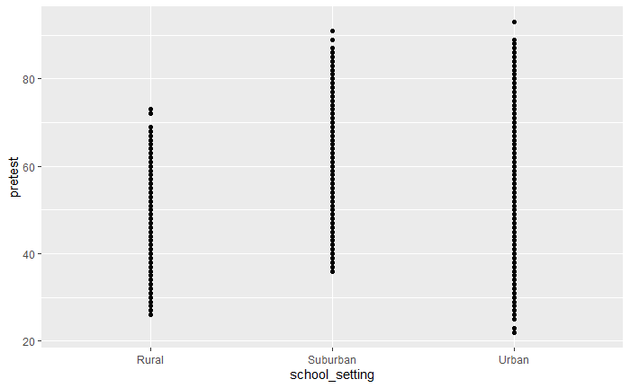

```r
ggplot(data=df,aes(x=school_setting, y=pretest)) + geom_point()
```

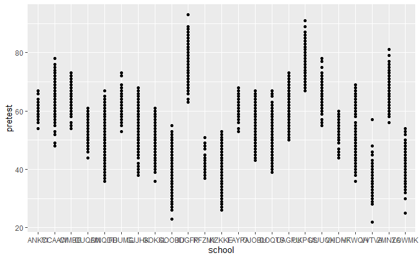

```r
ggplot(data=df,aes(x=school, y=pretest)) + geom_point()
```

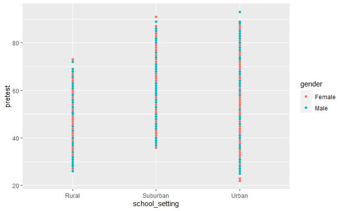

```r
ggplot(data=df,aes(x=school_setting, y=pretest, colour= gender)) + geom_point()
```

```r
table(df$teaching_method)
```

```
Experimental     Standard
         760         1373
```

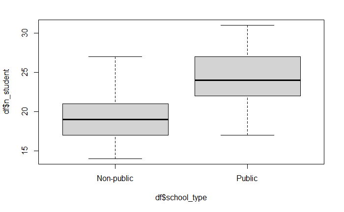

```r
boxplot(df$n_student ~ df$school_type, data=df)
```

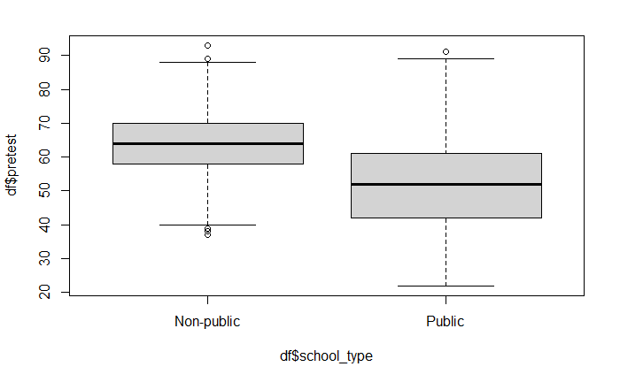

```r
boxplot(df$pretest ~ df$school_type, data=df)
```

```r
table(df$gender)
```

```
Female   Male
  1056   1077
```

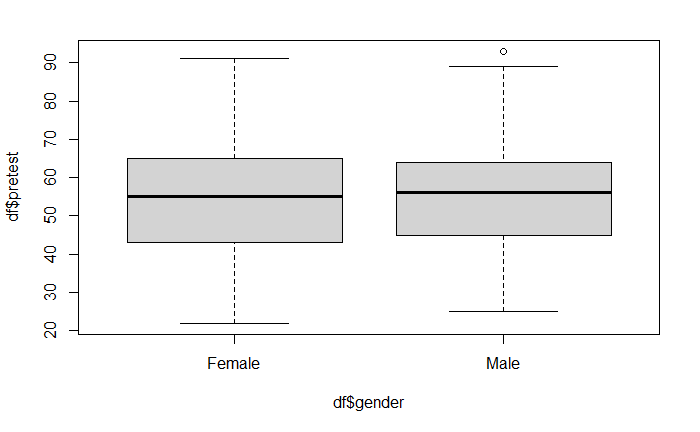

```r
boxplot(df$pretest ~ df$gender, data=df)
```

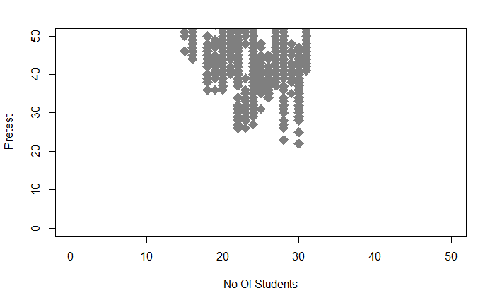

```r
plot(df$n_student,df$pretest, xlab = 'No Of Students', ylab = 'Pretest',
pch = 18, cex = 2, col = 'gray50', xlim = c(0, 50), ylim = c(0, 50))
```

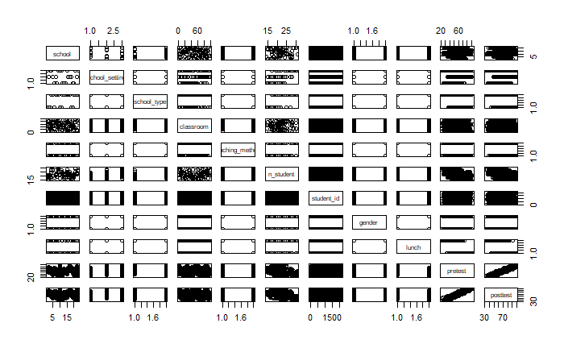

```r
plot(df)
```

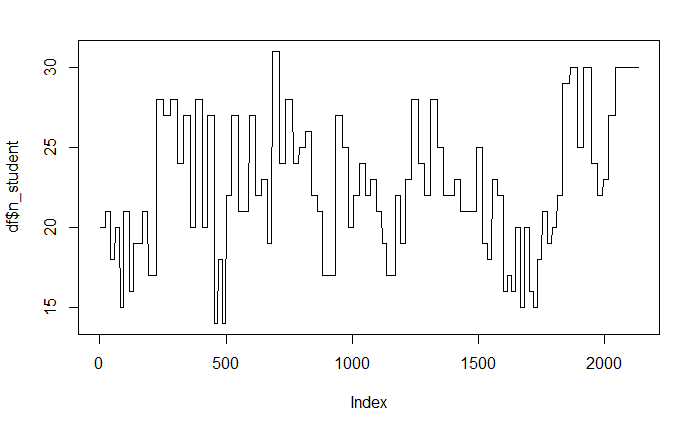

```r
plot(df$n_student,type = 'l')
```

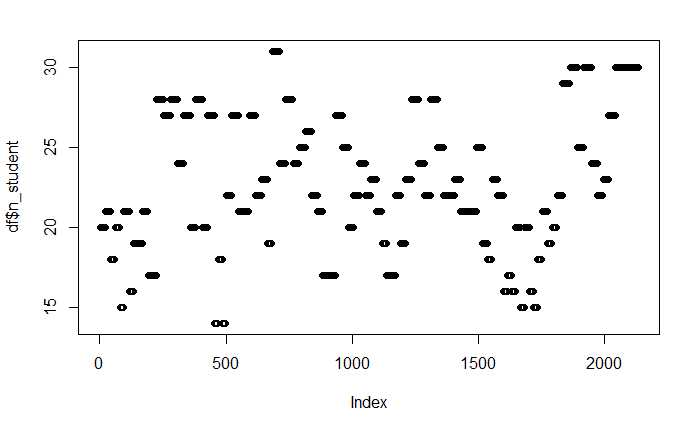

```r
plot(df$n_student,type = 'p')
```

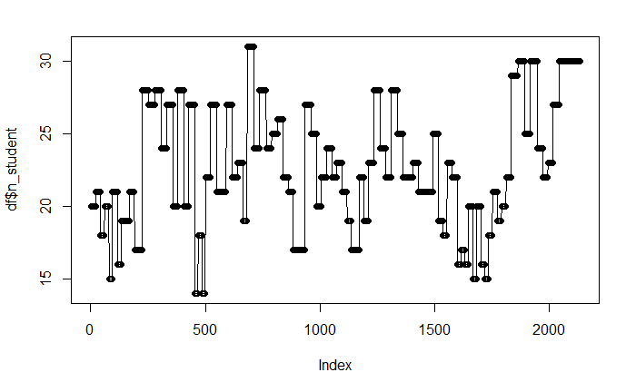

```r
plot(df$n_student,type = 'o')
```

```r
NA
NA
```

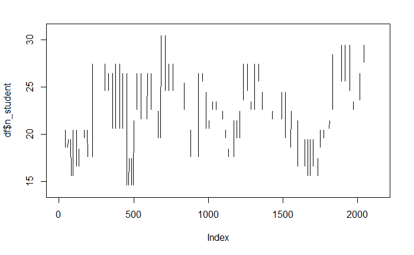

```r
plot(df$n_student,type = 'c')
```

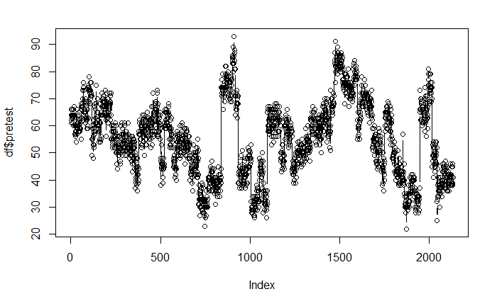

```r
plot(df$pretest, type='b')
```

[figure not shown]

```r
pie(df$n_student, clockwise = TRUE, init.angle = 180)
```

[figure not shown]

```r
dotchart(df$n_student)
```

[figure not shown]

```r
dotchart(df$n_student,color = 'gray30', gcolor = 'black', lcolor = 'gray30',
cex = 0.8, xlab = 'Student Counts', bg = 'gray90', pch = 21)
```

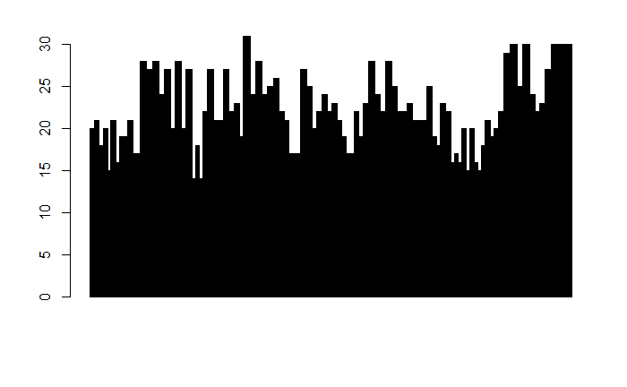

```r
barplot(df$n_student)
```

```r
df_matrix = data.matrix(df)
df_matrix
```

```
        school school_setting school_type classroom teaching_method n_student student_id gender lunch pretest
   [1,]      1              3           1        23               2        20        149      1     1      62
   [2,]      1              3           1        23               2        20        208      1     1      66
   [3,]      1              3           1        23               2        20        228      2     1      64
   [4,]      1              3           1        23               2        20        298      1     1      61
   [5,]      1              3           1        23               2        20        414      2     1      64
   [6,]      1              3           1        23               2        20        461      1     1      66
   [7,]      1              3           1        23               2        20        549      2     1      63
   [8,]      1              3           1        23               2        20        567      1     1      63
   [9,]      1              3           1        23               2        20        758      2     1      64
  [10,]      1              3           1        23               2        20        780      1     1      61
  [11,]      1              3           1        23               2        20        826      2     1      61
  [12,]      1              3           1        23               2        20        907      2     1      64
  [13,]      1              3           1        23               2        20       1150      2     1      66
  [14,]      1              3           1        23               2        20       1168      1     1      60
```

[output cut: 168 more lines]

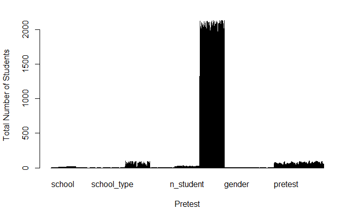

```r
barplot(df_matrix, beside = TRUE, ylab = 'Total Number of Students', xlab = 'Pretest')
```

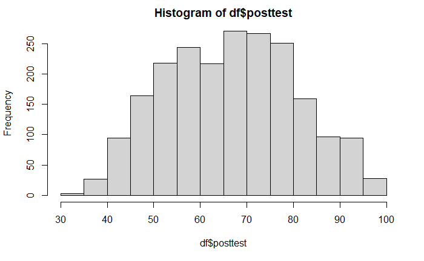

```r
hist(df$posttest)
```

Histogram of Pretest

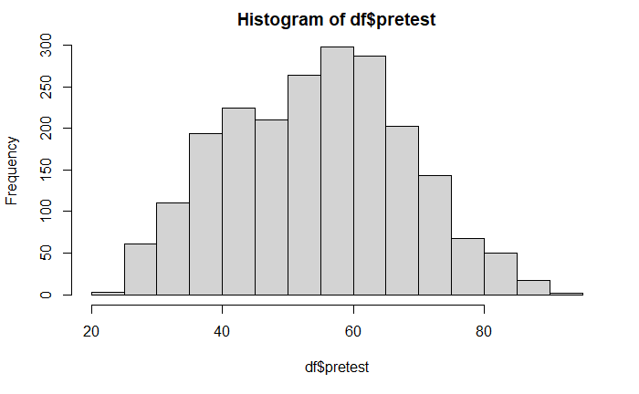

```r
hist(df$pretest)
```

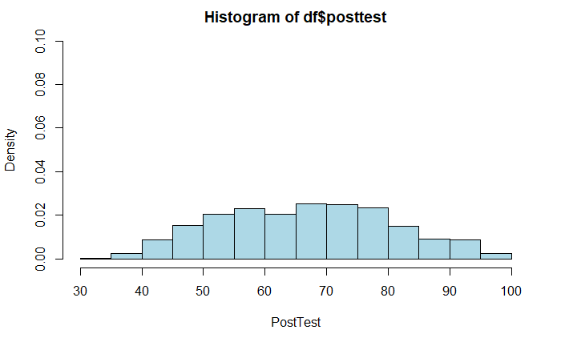

```r
hist(df$posttest, col = 'lightblue', xlab = 'PostTest', ylim = c(0, 0.1), freq = FALSE)
```

Using the Density Function to Draw a Graph

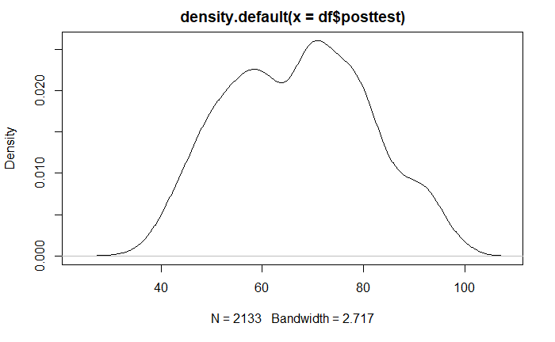

```r
plot(density(df$posttest))
```

```r
hist(df$posttest, freq = F)
lines(density(df$posttest), lty = 2)
```

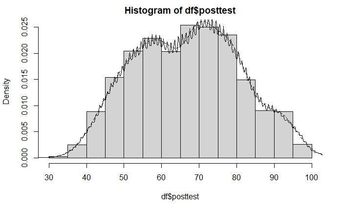

```r
lines(density(df$posttest, k = 'rectangular'))
```

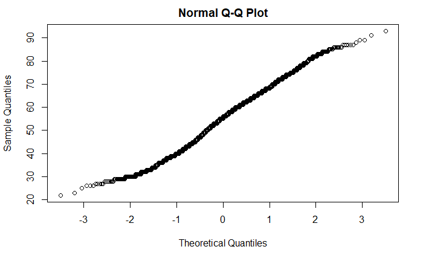

```r
qqnorm(df$pretest)
```

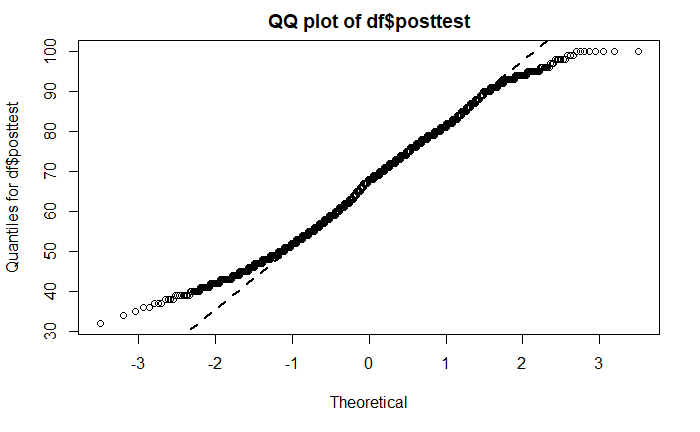

```r
qqnorm(df$posttest, main = 'QQ plot of df$posttest', xlab = 'Theoretical',
ylab = 'Quantiles for df$posttest')
qqline(df$posttest, lwd = 2, lty = 2)
```

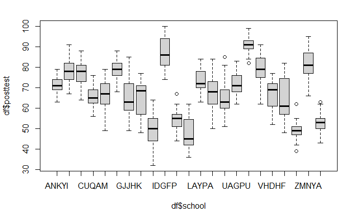

```r
boxplot(df$posttest ~ df$school, data = df)
```

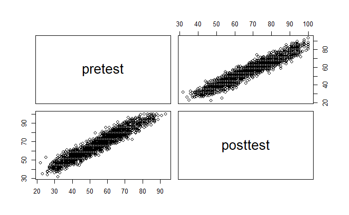

```r
pairs(~ pretest + posttest, data = df)
```

```r
library(dplyr)
```

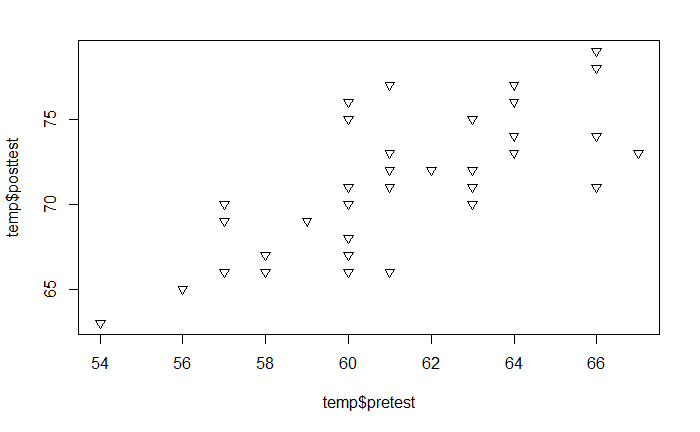

```r
temp = df %>% filter(df$school == "ANKYI")
plot(temp$pretest, temp$posttest, pch = 25)
```

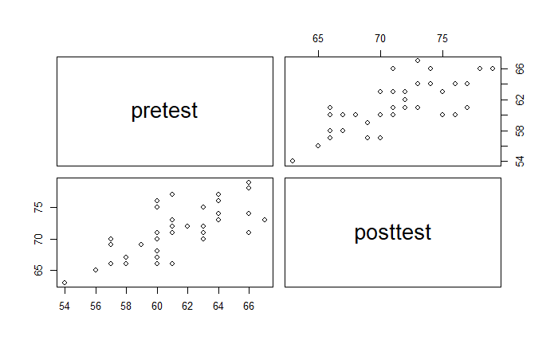

```r
pairs(~ pretest + posttest, data = temp)
```

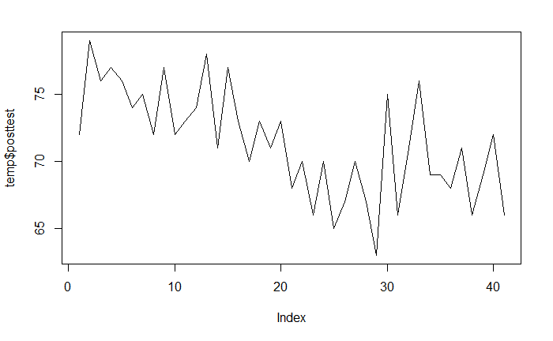

```r
plot(temp$posttest, type = 'l' )
```

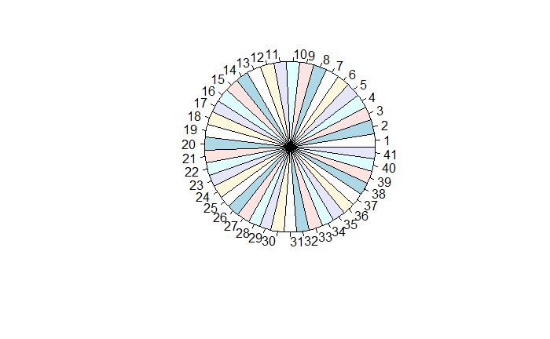

```r
pie(temp$posttest)
```

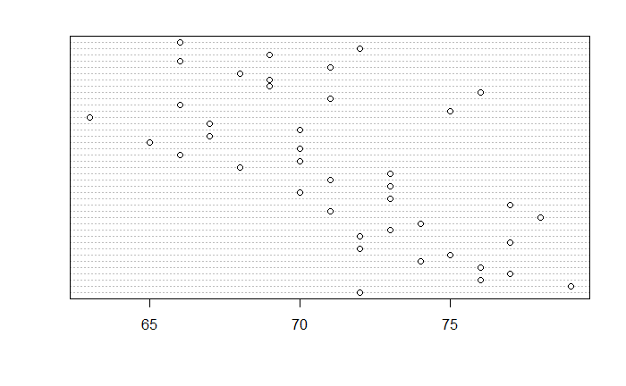

```r
dotchart(temp$posttest)
```